# adiv overtime alltimepoints

Matt Doherty

3/6/2017

# Stats

### Compare adiv of **treated** week 22 **responders** over each visit

```
##               USUBJID      INDTRTGR  RelRSPwk22   Week0adiv
##  C0743T26011500003: 1   Placebo: 0   No : 0     Min.   : 1.396
##  C0743T26011500004: 1   Treated:42   Yes:42     1st Qu.: 4.442
##  C0743T26011900002: 1                           Median : 6.509
##  C0743T26012400006: 1                           Mean   : 7.730
##  C0743T26012900005: 1                           3rd Qu.:11.060
##  C0743T26012900006: 1                           Max.   :18.353
##  (Other)          :36
##    Week4adiv        Week6adiv        Week22adiv
##  Min.   : 1.413   Min.   : 1.248   Min.   : 1.934
##  1st Qu.: 6.543   1st Qu.: 4.969   1st Qu.: 6.340
##  Median :10.121   Median : 9.157   Median :10.329
##  Mean   :12.311   Mean   :10.329   Mean   :11.587
##  3rd Qu.:17.162   3rd Qu.:14.897   3rd Qu.:15.445
##  Max.   :34.116   Max.   :22.792   Max.   :27.708
##
```

#### Summary showing 42 treated subjects who Responded at week 22 and alpha diversity measured by inverse Simpson at week 0, 4, 6, and 22.

```
##
##  Friedman rank sum test
##
## data:  alltp.treatedrespY.mat
## Friedman chi-squared = 19.486, df = 3, p-value = 0.0002169
```

#### Freidman.test result showing significant difference in alpha diversity based on time for treated Week 22 responders.

```
## Multiple comparisons between groups after Friedman test
## p.value: 0.05
## Comparisons
##     obs.dif critical.dif difference
## 1-2      44     31.21628       TRUE
## 1-3      34     31.21628       TRUE
## 1-4      46     31.21628       TRUE
## 2-3      10     31.21628      FALSE
## 2-4       2     31.21628      FALSE
## 3-4      12     31.21628      FALSE
```

#### Freidman multiple comparisons (friedmc) test result showing significant difference comparing weeks.

```r
pairwise.wilcox.test(ggplot.alltp.treatedrespY$invsimpson, ggplot.alltp.treatedrespY$visit,
    p.adj = "BH", exact = F, paired = T)
```

```
##
##  Pairwise comparisons using Wilcoxon signed rank test
##
## data:  ggplot.alltp.treatedrespY$invsimpson and ggplot.alltp.treatedrespY$visit
##
##         Screening Week 4 Week 6
## Week 4  0.029     -      -
## Week 6  0.164     0.367  -
## Week 22 0.029     0.910  0.373
##
## P value adjustment method: BH
```

#### An alternative multiple comparison test based on pairwise.wilcox.test using the “BH” p value adjustment showing significant differences between week 0 and wee 4 and 22 (but not week 6)

### Compare adiv of **treated** week 22 **NON**responders over each visit

```r
summary(alltp.treatedrespN)
```

```
##               USUBJID      INDTRTGR  RelRSPwk22   Week0adiv
##  C0743T26010300002: 1   Placebo: 0   No :59     Min.   : 1.350
##  C0743T26010300005: 1   Treated:59   Yes: 0     1st Qu.: 4.278
##  C0743T26010500003: 1                           Median : 6.546
##  C0743T26010900004: 1                           Mean   : 7.392
##  C0743T26011000001: 1                           3rd Qu.: 7.969
##  C0743T26011400007: 1                           Max.   :25.257
##  (Other)          :53
##    Week4adiv        Week6adiv        Week22adiv
##  Min.   : 1.581   Min.   : 1.067   Min.   : 1.156
##  1st Qu.: 3.559   1st Qu.: 3.324   1st Qu.: 3.677
##  Median : 5.316   Median : 5.186   Median : 6.513
##  Mean   : 7.266   Mean   : 6.302   Mean   : 7.843
##  3rd Qu.: 8.532   3rd Qu.: 8.082   3rd Qu.:10.348
##  Max.   :29.715   Max.   :20.532   Max.   :23.439
##
```

#### Summary showing 59 treated subjects who did not responded at week 22 and alpha diversity measured by inverse Simpson at week 0, 4, 6, and 22.

```
##
##  Friedman rank sum test
##
## data:  alltp.treatedrespN.mat
## Friedman chi-squared = 4.7492, df = 3, p-value = 0.1911
```

#### Freidman.test result showing no significant difference in alpha diversity based on time in treated Week 22 nonresponders.

### Compare adiv of **placebo** week 22 **responders** over each visit

```r
summary(alltp.placeborespY)
```

```
##               USUBJID     INDTRTGR  RelRSPwk22   Week0adiv
##  C0743T26013600003:1   Placebo:10   No : 0     Min.   : 2.287
##  C0743T26019300005:1   Treated: 0   Yes:10     1st Qu.: 5.221
##  C0743T26026000003:1                           Median : 8.732
##  C0743T26028200001:1                           Mean   :10.770
##  C0743T26035100009:1                           3rd Qu.:14.243
##  C0743T26040100004:1                           Max.   :22.284
##  (Other)          :4
##    Week4adiv        Week6adiv        Week22adiv
##  Min.   : 2.145   Min.   : 2.441   Min.   : 2.161
##  1st Qu.: 6.118   1st Qu.: 3.439   1st Qu.: 6.678
##  Median : 8.075   Median : 7.589   Median : 8.530
##  Mean   : 9.265   Mean   : 8.715   Mean   :11.965
##  3rd Qu.:13.716   3rd Qu.:12.835   3rd Qu.:10.607
##  Max.   :15.493   Max.   :19.171   Max.   :34.171
##
```

#### Summary showing 10 placebo subjects who responded at week 22 and alpha diversity measured by inverse Simpson at week 0, 4, 6, and 22.

```
##
##  Friedman rank sum test
##
## data:  alltp.placeborespY.mat
## Friedman chi-squared = 0.36, df = 3, p-value = 0.9484
```

#### No significant difference by Friedman test.

### Compare adiv of **placebo** week 22 **NON**responders over each visit

```r
summary(alltp.placeborespN)
```

```
##               USUBJID     INDTRTGR RelRSPwk22   Week0adiv
##  C0743T26035300005:1   Placebo:4   No :4      Min.   : 4.444
##  C0743T26040800002:1   Treated:0   Yes:0      1st Qu.: 8.252
##  C0743T26045800005:1                          Median :14.279
##  C0743T26061000001:1                          Mean   :14.615
##  C0743T26010200002:0                          3rd Qu.:20.642
##  C0743T26010200003:0                          Max.   :25.457
##  (Other)          :0
##    Week4adiv        Week6adiv        Week22adiv
##  Min.   : 5.550   Min.   : 7.179   Min.   : 3.439
##  1st Qu.: 6.772   1st Qu.: 8.742   1st Qu.: 6.038
##  Median :11.114   Median :16.626   Median : 8.239
##  Mean   :13.376   Mean   :16.607   Mean   : 9.265
##  3rd Qu.:17.718   3rd Qu.:24.491   3rd Qu.:11.466
##  Max.   :25.728   Max.   :25.996   Max.   :17.143
##
```

#### Summary showing 4 placebo subjects who did not responded at week 22 and alpha diversity measured by inverse Simpson at week 0, 4, 6, and 22.

```
##
##  Friedman rank sum test
##
## data:  alltp.placeborespN.mat
## Friedman chi-squared = 2.1, df = 3, p-value = 0.5519
```

#### No significant difference by Friedman test.

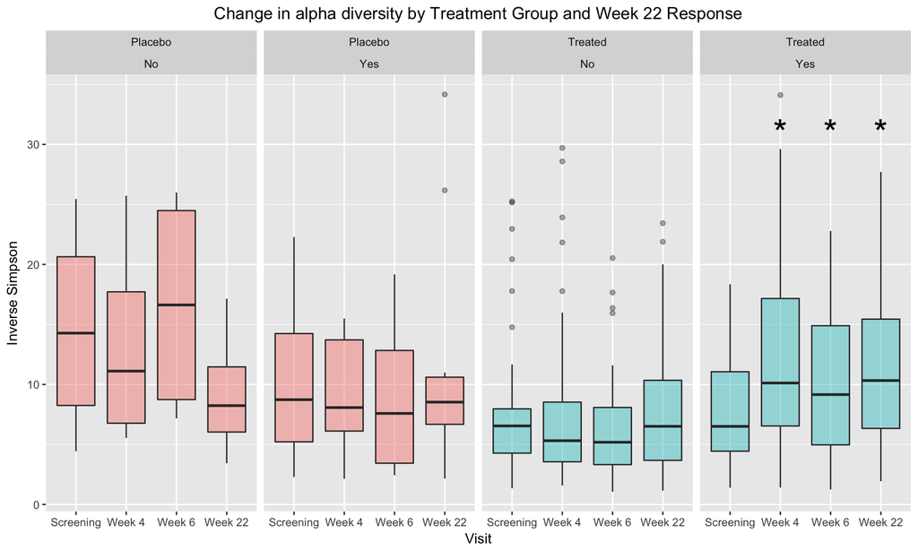

### * = significantly different from week 0 by freidmc test

#### Figure showing differences in alpha diversity over time by treatment group and response.